# QC_seurat_cut_filtrado

## Asignar tipo celular a los clusters:

Cluster ID Markers Cell Type

0 IL7R, CCR7 Naive CD4+ T

1 CD14, LYZ CD14+ Mono

2 IL7R, S100A4 Memory CD4+

3 MS4A1 B

4 CD8A CD8+ T

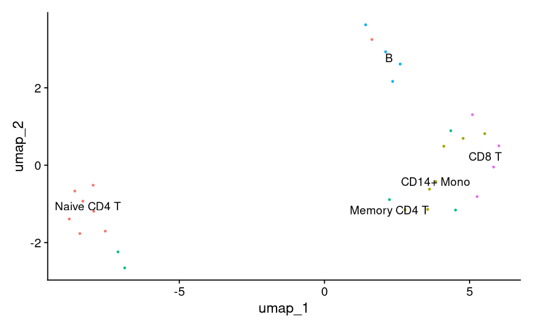

```r
new.cluster.ids <- c("Naive CD4 T", "CD14+ Mono", "Memory CD4 T", "B", "CD8 T", "FCGR3A+ Mono",
    "NK", "DC", "Platelet")
names(new.cluster.ids) <- levels(seurat_cut_filtrado)
seurat_cut_filtrado <- RenameIdents(seurat_cut_filtrado, new.cluster.ids)
figure_q = DimPlot(seurat_cut_filtrado, reduction = "umap", label = TRUE, pt.size = 0.5) + NoLegend()
figure_q
ggsave(filename = "../figures/figure_q.jpg",
       plot = figure_q,
       height = 7, width = 12,
       quality = 50)
```

Aunque pusimos estos nombres, no necesariamente indican el tipo celular exacto. Cluster 0: no se ven datos específicos de CD4 T. Cluster 1: tiene moléculas de linfocitos T en realidad Cluster 2: los genes apuntan a mieloide en realidad. Cluster 3: sí es de linfocitos B

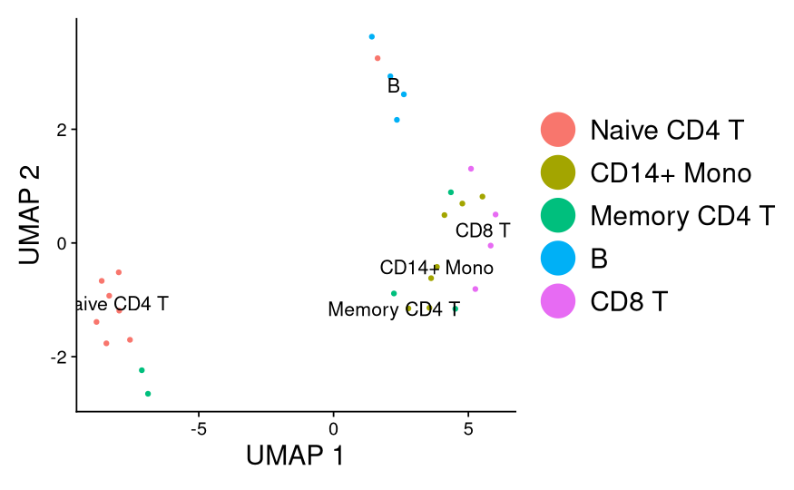

```r
library(ggplot2)
figure_r <- DimPlot(seurat_cut_filtrado, reduction = "umap", label = TRUE, label.size = 4.5) + xlab("UMAP 1") + ylab("UMAP 2") +
    theme(axis.title = element_text(size = 18), legend.text = element_text(size = 18)) + guides(colour = guide_legend(override.aes = list(size = 10)))

figure_r
ggsave(filename = "../figures/figure_r.jpg",
       plot = figure_r,
       height = 7, width = 12,
       quality = 50)
```